# Analisa Emisi Global dengan Teknik Deskriptif dan Clustering

Proyek analisa ini dikerjakan sebagai bentuk pembelajaran dan penarapan ilmu-ilmu analisa yang telah dipelajari.

### Pendahuluan

Selamat datang dalam RNotebook ini yang akan membahas proyek mengenai emisi global. Proyek ini bertujuan untuk menganalisis dan memahami pola emisi gas rumah kaca utama, seperti CO2, CH4, dan N2O, yang berkontribusi terhadap perubahan iklim global. Emisi gas rumah kaca merupakan isu yang sangat penting dalam lingkup global karena memiliki dampak yang signifikan terhadap keseimbangan ekosistem bumi dan kualitas hidup manusia.

Latar belakang pentingnya proyek ini adalah untuk memahami sejauh mana aktivitas manusia, seperti produksi energi, transportasi, industri, dan pertanian, berkontribusi terhadap emisi gas rumah kaca. Dengan mempelajari tren emisi dari berbagai negara, kita dapat mengidentifikasi negara-negara dengan emisi tertinggi dan merumuskan strategi pengurangan emisi yang efektif. Selain itu, proyek ini juga akan melihat hubungan antara emisi CO2 dengan faktor-faktor lain seperti pertumbuhan ekonomi dan populasi, sehingga memberikan wawasan mengenai peran ekonomi dan demografi dalam pola emisi global.

Dengan menggunakan bahasa pemrograman R dan berbagai paket analisis data, kita akan melakukan eksplorasi data, membersihkan dan mempersiapkan data, melakukan analisis statistik, dan membuat visualisasi yang informatif. Semoga proyek ini dapat memberikan wawasan yang berharga dalam memahami permasalahan emisi global dan menginspirasi langkah-langkah keberlanjutan yang lebih baik untuk masa depan bumi kita.

#### Memuat paket-paket yang relevan dan mengimpor data

Pada proyek ini kami akan menggunakan beberapa paket yang relevan, seperti ‘dplyr’, ‘ggplot2’, dan ‘cluster’ yang mana berguna untuk analisa klaster.

```r
library(dplyr)
library(ggplot2)
library(readr)
library(cluster)
```

```r
df <- read.csv("/Users/mac/r_notebook_project/global_emissions.csv")
head(df)
```

|  | Year | Country.Name | Country.Code | Country.GDP | Country.Population | Emissions.Production.CH4 | Emissions.Production.N2O | Emissions.Production.CO2.Cement | Emissions.Production.CO2.Coal | Emissions.Production.CO2.Gas | Emissions.Production.CO2.Oil | Emissions.Production.CO2.Flaring | Emissions.Production.CO2.Other | Emissions.Production.CO2.Total | Emissions.Global.Share.CO2.Cement | Emissions.Global.Share.CO2.Coal | Emissions.Global.Share.CO2.Gas | Emissions.Global.Share.CO2.Oil | Emissions.Global.Share.CO2.Flaring | Emissions.Global.Share.CO2.Total |
| --- | --- | --- | --- | --- | --- | --- | --- | --- | --- | --- | --- | --- | --- | --- | --- | --- | --- | --- | --- | --- |
| 1 | 1992 | Afghanistan | AFG | 12677538816 | 14485543 | 7.13 | 2.89 | 0.046 | 0.022 | 0.363 | 0.927 | 0.022 | 0.000000e+00 | 1.379 | 0.01 | 0 | 0.01 | 0.01 | 0.01 | 0.01 |
| 2 | 1993 | Afghanistan | AFG | 9834580992 | 15816601 | 7.21 | 2.93 | 0.047 | 0.018 | 0.352 | 0.894 | 0.022 | 0.000000e+00 | 1.333 | 0.01 | 0 | 0.01 | 0.01 | 0.01 | 0.01 |
| 3 | 1994 | Afghanistan | AFG | 7919857152 | 17075728 | 7.47 | 2.76 | 0.047 | 0.015 | 0.338 | 0.860 | 0.022 | 2.220446e-16 | 1.282 | 0.01 | 0 | 0.01 | 0.01 | 0.01 | 0.01 |
| 4 | 1995 | Afghanistan | AFG | 12307525632 | 18110662 | 7.83 | 2.88 | 0.047 | 0.015 | 0.322 | 0.824 | 0.022 | 2.220446e-16 | 1.230 | 0.01 | 0 | 0.01 | 0.01 | 0.01 | 0.01 |
| 5 | 1996 | Afghanistan | AFG | 12070125568 | 18853444 | 8.67 | 3.12 | 0.047 | 0.007 | 0.308 | 0.780 | 0.022 | 1.000000e-03 | 1.165 | 0.01 | 0 | 0.01 | 0.01 | 0.01 | 0.00 |
| 6 | 1997 | Afghanistan | AFG | 11850752000 | 19357126 | 9.40 | 3.43 | 0.047 | 0.004 | 0.283 | 0.728 | 0.022 | 2.220446e-16 | 1.084 | 0.01 | 0 | 0.01 | 0.01 | 0.01 | 0.00 |

### Data Pre-processing

```r
df <- na.omit(df)
df <- distinct(df)
colnames(df) <- c(
  "year", "country", "country_code", "country_gdp", "population",
  "ch4_prod", "n2o_prod", "co2_cement_prod", "co2_coal_prod",
  "co2_gas_prod", "co2_oil_prod", "co2_flare_prod", "co2_other_prod",
  "total_prod", "co2_cement_global", "co2_coal_global", "co2_gas_global",
  "co2_oil_global", "co2_flare_global", "total_global"
)

head(df)
```

|  | year | country | country_code | country_gdp | population | ch4_prod | n2o_prod | co2_cement_prod | co2_coal_prod | co2_gas_prod | co2_oil_prod | co2_flare_prod | co2_other_prod | total_prod | co2_cement_global | co2_coal_global | co2_gas_global | co2_oil_global | co2_flare_global | total_global |
| --- | --- | --- | --- | --- | --- | --- | --- | --- | --- | --- | --- | --- | --- | --- | --- | --- | --- | --- | --- | --- |
| 1 | 1992 | Afghanistan | AFG | 12677538816 | 14485543 | 7.13 | 2.89 | 0.046 | 0.022 | 0.363 | 0.927 | 0.022 | 0.000000e+00 | 1.379 | 0.01 | 0 | 0.01 | 0.01 | 0.01 | 0.01 |
| 2 | 1993 | Afghanistan | AFG | 9834580992 | 15816601 | 7.21 | 2.93 | 0.047 | 0.018 | 0.352 | 0.894 | 0.022 | 0.000000e+00 | 1.333 | 0.01 | 0 | 0.01 | 0.01 | 0.01 | 0.01 |
| 3 | 1994 | Afghanistan | AFG | 7919857152 | 17075728 | 7.47 | 2.76 | 0.047 | 0.015 | 0.338 | 0.860 | 0.022 | 2.220446e-16 | 1.282 | 0.01 | 0 | 0.01 | 0.01 | 0.01 | 0.01 |
| 4 | 1995 | Afghanistan | AFG | 12307525632 | 18110662 | 7.83 | 2.88 | 0.047 | 0.015 | 0.322 | 0.824 | 0.022 | 2.220446e-16 | 1.230 | 0.01 | 0 | 0.01 | 0.01 | 0.01 | 0.01 |
| 5 | 1996 | Afghanistan | AFG | 12070125568 | 18853444 | 8.67 | 3.12 | 0.047 | 0.007 | 0.308 | 0.780 | 0.022 | 1.000000e-03 | 1.165 | 0.01 | 0 | 0.01 | 0.01 | 0.01 | 0.00 |
| 6 | 1997 | Afghanistan | AFG | 11850752000 | 19357126 | 9.40 | 3.43 | 0.047 | 0.004 | 0.283 | 0.728 | 0.022 | 2.220446e-16 | 1.084 | 0.01 | 0 | 0.01 | 0.01 | 0.01 | 0.00 |

Melakukan pembersihan data, menghilangkan nilai yang kosong, duplikat dan transformasi data, termasuk mengubah nama kolom supaya terlihat representatif.

```r
# cek tipe data masing-masing atribut
column_types <- sapply(df, class)
print(column_types)
```

```
             year           country      country_code       country_gdp
        "integer"       "character"       "character"         "numeric"
       population          ch4_prod          n2o_prod   co2_cement_prod
        "integer"         "numeric"         "numeric"         "numeric"
    co2_coal_prod      co2_gas_prod      co2_oil_prod    co2_flare_prod
        "numeric"         "numeric"         "numeric"         "numeric"
   co2_other_prod        total_prod co2_cement_global   co2_coal_global
        "numeric"         "numeric"         "numeric"         "numeric"
   co2_gas_global    co2_oil_global  co2_flare_global      total_global
        "numeric"         "numeric"         "numeric"         "numeric"
```

```r
# mengubah kolom tahun menjadi tipe data string
df$year <- as.character(df$year)
emission_df <- sapply(df, class)
print(emission_df)
```

```
             year           country      country_code       country_gdp
      "character"       "character"       "character"         "numeric"
       population          ch4_prod          n2o_prod   co2_cement_prod
        "integer"         "numeric"         "numeric"         "numeric"
    co2_coal_prod      co2_gas_prod      co2_oil_prod    co2_flare_prod
        "numeric"         "numeric"         "numeric"         "numeric"
   co2_other_prod        total_prod co2_cement_global   co2_coal_global
        "numeric"         "numeric"         "numeric"         "numeric"
   co2_gas_global    co2_oil_global  co2_flare_global      total_global
        "numeric"         "numeric"         "numeric"         "numeric"
```

```r
emission_df <- df # Membuat 'emission_df' dataframe
```

Summarize data untuk melihat rata-rata dan median serta parameter lain

```r
summary(emission_df)
```

```
     year             country          country_code        country_gdp
 Length:2484        Length:2484        Length:2484        Min.   :0.000e+00
 Class :character   Class :character   Class :character   1st Qu.:6.145e+10
 Mode  :character   Mode  :character   Mode  :character   Median :2.249e+11
                                                          Mean   :7.910e+11
                                                          3rd Qu.:6.051e+11
                                                          Max.   :1.815e+13
   population           ch4_prod          n2o_prod      co2_cement_prod
 Min.   :2.602e+05   Min.   :   0.52   Min.   :  0.11   Min.   :  0.0000
 1st Qu.:5.074e+06   1st Qu.:   7.46   1st Qu.:  2.55   1st Qu.:  0.5428
 Median :1.540e+07   Median :  22.84   Median :  7.49   Median :  1.8300
 Mean   :6.264e+07   Mean   :  71.83   Mean   : 24.56   Mean   : 10.6165
 3rd Qu.:4.885e+07   3rd Qu.:  66.03   3rd Qu.: 21.88   3rd Qu.:  6.2865
 Max.   :1.428e+09   Max.   :1161.42   Max.   :552.67   Max.   :786.7450
 co2_coal_prod       co2_gas_prod       co2_oil_prod      co2_flare_prod
 Min.   :   0.000   Min.   :   0.000   Min.   :   0.366   Min.   : 0.000
 1st Qu.:   0.310   1st Qu.:   2.553   1st Qu.:   8.947   1st Qu.: 0.000
 Median :   7.394   Median :  12.499   Median :  29.233   Median : 0.241
 Mean   : 123.146   Mean   :  58.088   Mean   : 102.179   Mean   : 3.371
 3rd Qu.:  41.942   3rd Qu.:  55.053   3rd Qu.:  73.189   3rd Qu.: 2.583
 Max.   :7493.455   Max.   :1641.041   Max.   :2608.477   Max.   :76.211
 co2_other_prod      total_prod        co2_cement_global co2_coal_global
 Min.   :  0.000   Min.   :    0.758   Min.   : 0.000    Min.   : 0.00
 1st Qu.:  0.000   1st Qu.:   21.525   1st Qu.: 0.060    1st Qu.: 0.00
 Median :  0.001   Median :   60.908   Median : 0.190    Median : 0.06
 Mean   :  2.677   Mean   :  300.077   Mean   : 1.049    Mean   : 1.06
 3rd Qu.:  1.054   3rd Qu.:  220.066   3rd Qu.: 0.620    3rd Qu.: 0.36
 Max.   :171.537   Max.   :10289.989   Max.   :52.750    Max.   :49.93
 co2_gas_global   co2_oil_global    co2_flare_global  total_global
 Min.   : 0.000   Min.   : 0.0000   Min.   : 0.000   Min.   : 0.0000
 1st Qu.: 0.050   1st Qu.: 0.0800   1st Qu.: 0.000   1st Qu.: 0.0800
 Median : 0.240   Median : 0.2800   Median : 0.070   Median : 0.2200
 Mean   : 1.061   Mean   : 0.9519   Mean   : 1.073   Mean   : 1.0207
 3rd Qu.: 1.010   3rd Qu.: 0.6900   3rd Qu.: 0.790   3rd Qu.: 0.7225
 Max.   :28.340   Max.   :24.0100   Max.   :18.020   Max.   :28.2100
```

### Analyze Process

Pada tahap ini kita akan menjawab beberapa pertanyaan berdasarkan tujuan analisa kita.

**Pertanyaan 1** Bagaimana tren emisi global CH4, N2O, dan CO2 dari tahun ke tahun?

```r
# menggabungkan atau menjumlahkan nilai total CO2
co_total <- emission_df %>%
  mutate(co2_total_emission = total_prod + total_global)
head(co_total)
```

|  | year | country | country_code | country_gdp | population | ch4_prod | n2o_prod | co2_cement_prod | co2_coal_prod | co2_gas_prod | co2_oil_prod | co2_flare_prod | co2_other_prod | total_prod | co2_cement_global | co2_coal_global | co2_gas_global | co2_oil_global | co2_flare_global | total_global | co2_total_emission |
| --- | --- | --- | --- | --- | --- | --- | --- | --- | --- | --- | --- | --- | --- | --- | --- | --- | --- | --- | --- | --- | --- |
| 1 | 1992 | Afghanistan | AFG | 12677538816 | 14485543 | 7.13 | 2.89 | 0.046 | 0.022 | 0.363 | 0.927 | 0.022 | 0.000000e+00 | 1.379 | 0.01 | 0 | 0.01 | 0.01 | 0.01 | 0.01 | 1.389 |
| 2 | 1993 | Afghanistan | AFG | 9834580992 | 15816601 | 7.21 | 2.93 | 0.047 | 0.018 | 0.352 | 0.894 | 0.022 | 0.000000e+00 | 1.333 | 0.01 | 0 | 0.01 | 0.01 | 0.01 | 0.01 | 1.343 |
| 3 | 1994 | Afghanistan | AFG | 7919857152 | 17075728 | 7.47 | 2.76 | 0.047 | 0.015 | 0.338 | 0.860 | 0.022 | 2.220446e-16 | 1.282 | 0.01 | 0 | 0.01 | 0.01 | 0.01 | 0.01 | 1.292 |
| 4 | 1995 | Afghanistan | AFG | 12307525632 | 18110662 | 7.83 | 2.88 | 0.047 | 0.015 | 0.322 | 0.824 | 0.022 | 2.220446e-16 | 1.230 | 0.01 | 0 | 0.01 | 0.01 | 0.01 | 0.01 | 1.240 |
| 5 | 1996 | Afghanistan | AFG | 12070125568 | 18853444 | 8.67 | 3.12 | 0.047 | 0.007 | 0.308 | 0.780 | 0.022 | 1.000000e-03 | 1.165 | 0.01 | 0 | 0.01 | 0.01 | 0.01 | 0.00 | 1.165 |
| 6 | 1997 | Afghanistan | AFG | 11850752000 | 19357126 | 9.40 | 3.43 | 0.047 | 0.004 | 0.283 | 0.728 | 0.022 | 2.220446e-16 | 1.084 | 0.01 | 0 | 0.01 | 0.01 | 0.01 | 0.00 | 1.084 |

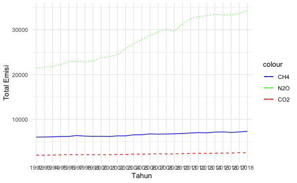

```r
# Mengelompokkan data berdasarkan tahun dan menghitung total emisi CH4, N2O, dan CO2
yearly_emission <- co_total %>%
  group_by(year) %>%
  summarize(Total_CH4 = sum(ch4_prod),
            Total_N2O = sum(n2o_prod),
            Total_CO2 = sum(co2_total_emission))
# Visualisasi tren emisi dengan membuat plot garis untuk tren emisi CH4, N2O, dan CO2
ggplot(data = yearly_emission, aes(x = year, group = 1)) + # menambahkan angka 1 pada estetika agar ggplot menganggap data adalah satu kelompok
  geom_line(aes(y = Total_CH4, color = "CH4"), linetype = "solid") +
  geom_line(aes(y = Total_N2O, color = "N2O"), linetype = "dashed") +
  geom_line(aes(y = Total_CO2, color = "CO2"), linetype = "dotted") +
  xlab("Tahun") +
  ylab("Total Emisi") +
  scale_color_manual(values = c("CH4" = "blue", "N2O" = "red", "CO2" = "green"),
                     labels = c("CH4", "N2O", "CO2")) +
  theme_minimal()
```

**Pertanyaan 2** Negara mana yang memiliki emisi CO2 tertinggi? Bagaimana perbandingannya dengan GDP dan populasi negara tersebut?

```r
# Menghitung total emisi CO2, gdp, dan populasi per negara
co2_by_country <- co_total %>%
  group_by(country) %>%
  summarise(total_co2 = sum(co2_total_emission)) %>%
  arrange(desc(total_co2))

gdp_by_country <- emission_df %>%
  group_by(country) %>%
  summarise(total_gdp = sum(country_gdp)) %>%
  arrange(desc(total_gdp))

population_by_country <- emission_df %>%
  group_by(country) %>%
  summarise(total_population = sum(population)) %>%
  arrange(desc(total_population))

# Menggabungkan data emisi CO2 dengan data GDP dan populasi
merged_data <- merge(co2_by_country, gdp_by_country, by = "country", all.x = TRUE) %>%
  merge(population_by_country, by = "country", all.x = TRUE)

# Mencari negara dengan emisi CO2 tertinggi
highest_co_country <- merged_data %>%
  filter(total_co2 == max(total_co2))

highest_co_country
```

| country | total_co2 | total_gdp | total_population |
| --- | --- | --- | --- |
| China | 169342.3 | 2.655735e+14 | 35819355392 |

Insight yang dapat diambil dari perbandingan ini adalah sebagai berikut:

China memiliki emisi CO2 yang sangat tinggi dibandingkan dengan negara-negara lain yang terdapat dalam dataset tersebut. Hal ini menunjukkan kontribusi yang signifikan dari China terhadap emisi CO2 global. GDP China yang tinggi (tertinggi ke-2 setelah Amerika Serikat) menunjukkan bahwa negara ini memiliki ekonomi yang kuat dan besar. Hubungan antara GDP dan emisi CO2 perlu dipertimbangkan untuk memahami dampak aktivitas ekonomi terhadap lingkungan. Dengan populasi yang sangat besar, China memiliki tantangan tersendiri dalam mengelola emisi CO2 dan mempertahankan pertumbuhan ekonomi yang berkelanjutan. Perhatian terhadap efisiensi energi, sumber energi terbarukan, dan kebijakan lingkungan yang efektif sangat penting bagi negara dengan populasi sebesar China.

**Pertanyaan 3** Apakah ada hubungan antara pertumbuhan GDP suatu negara dengan emisi CO2?

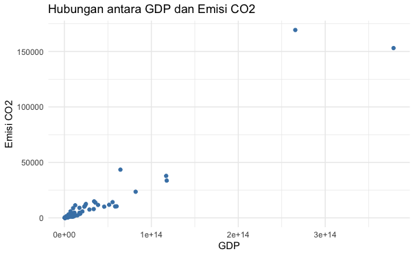

```r
# Menggabungkan data GDP dan emisi CO2
gdp_x_co2 <- merge(gdp_by_country, co2_by_country, by = "country", all.x = TRUE)

top_10_countries <- gdp_x_co2 %>%
  arrange(desc(total_gdp)) %>%
  head(10)

# Membuat scatter plot
ggplot(gdp_x_co2, aes(x = total_gdp, y = total_co2)) +
  geom_point(color = "steelblue") +
  labs(title = "Hubungan antara GDP dan Emisi CO2",
       x = "GDP",
       y = "Emisi CO2") +
  theme_minimal()
```

Bagaimana hubungan dengan emisi CH4

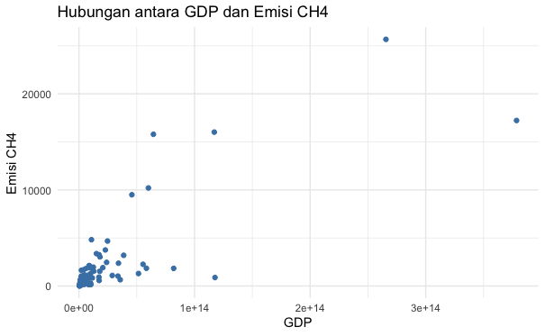

```r
ch4_by_country <- co_total %>%
  group_by(country) %>%
  summarise(total_ch4 = sum(ch4_prod)) %>%
  arrange(desc(total_ch4))
gdp_x_ch4 <- merge(gdp_by_country, ch4_by_country, by = "country", all.x = TRUE)
# Membuat scatter plot
ggplot(gdp_x_ch4, aes(x = total_gdp, y = total_ch4)) +
  geom_point(color = "steelblue") +
  labs(title = "Hubungan antara GDP dan Emisi CH4",
       x = "GDP",
       y = "Emisi CH4") +
  theme_minimal()
```

**Pertanyaan 4** Bagaimanakah hubungan yang ditunjukkan antara populasi dari negara dengan emisi CO2?

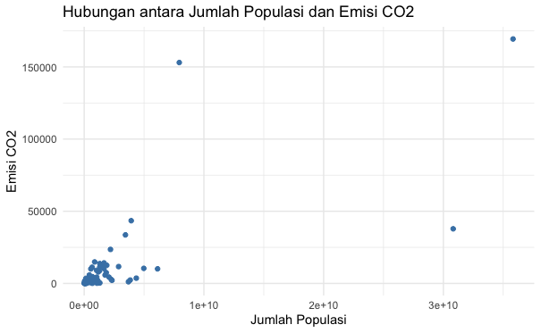

```r
# Mmebuat dataframe berisikan total populasi tiap negara dengan total emisi CO2
population_x_co2 <- merge(population_by_country, co2_by_country, by = "country", all.x = TRUE)
# Membuat scatter plot untuk mengetahui polanya
ggplot(population_x_co2, aes(x = total_population, y = total_co2)) +
  geom_point(color = "steelblue") +
  labs(title = "Hubungan antara Jumlah Populasi dan Emisi CO2",
       x = "Jumlah Populasi",
       y = "Emisi CO2") +
  theme_minimal()
```

Sejauh yang dapat kami perkirakan jumlah populasi tidak terlalu berkontribusi terhadap tingginya emisi CO2 suatu negara, hal itu ditunjukkan dengan adanya hubungan positif yang lemah.

**Pertanyaan 5** Apa kontribusi masing-masing sumber emisi CO2 (seperti batu bara, minyak, gas, pembakaran) terhadap total emisi global?

```r
# Mengelompokkan masing-masing kategori dan menjumlahkan value masing-masing
cement <- emission_df %>%
  mutate(total_cement = co2_cement_prod + co2_cement_global)
coal <- emission_df %>%
  mutate(total_coal = co2_coal_prod + co2_coal_global)
gas <- emission_df %>%
  mutate(total_gas = co2_gas_prod + co2_gas_global)
oil <- emission_df %>%
  mutate(total_oil = co2_oil_prod + co2_oil_global)
flaring <- emission_df %>%
  mutate(total_flaring = co2_flare_prod + co2_flare_global)

# Menggabungkan tiap-tiap kategori kedalam dataframe
data_cement <- cement$total_cement
data_coal <- coal$total_coal
data_gas <- gas$total_gas
data_oil <- oil$total_oil
data_flaring <- flaring$total_flaring

# Menghitung total emisi untuk masing-masing sumber
total_emission <- data_cement + data_coal + data_gas + data_oil + data_flaring
```

Telah didapatkan value-value yang merepresentasikan sebagai sumber dari emisi CO2, selanjutnya membuat dataframe dari sumber-sumber yang sudah terdefinisi kemudian menghitung persentase kontribusi masing-masing sumber.

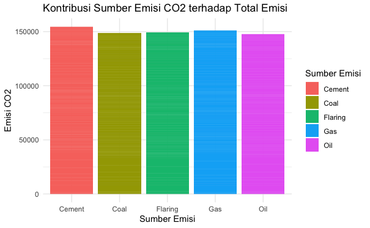

```r
# Membuat dataframe baru dengan kontribusi masing-masing sumber emisi
emission_contributions <- data.frame(source = c("Cement", "Flaring", "Coal", "Oil", "Gas"),
                                     emission = c(data_cement, data_flaring, data_coal, data_oil, data_gas),
                                     total_emission = total_emission)

# Menghitung persentase kontribusi masing-masing sumber emisi
emission_contributions <- emission_contributions %>%
  mutate(percentage = emission / sum(emission) * 100)

# Visualisasikan kedalam stacked bar
bar_chart <- ggplot(emission_contributions, aes(x = source, y = emission, fill = source)) +
  geom_bar(stat = "identity") +
  labs(title = "Kontribusi Sumber Emisi CO2 terhadap Total Emisi",
       x = "Sumber Emisi",
       y = "Emisi CO2",
       fill = "Sumber Emisi") +
  theme_minimal()
print(bar_chart)
```

**Pertanyaan 6** Bagaimana perbandingan emisi CO2 per kapita antara negara-negara?

```r
# Menghitung emisi CO2 per kapita
co2_population <- population_x_co2 %>%
  mutate(co2_per_capita = total_co2 / total_population)

# Menampilkan hasil perbandingan emisi CO2 per kapita
co2_population <- co2_population %>%
  select(country, co2_per_capita)

# Mengurutkan data berdasarkan emisi CO2 per kapita
co2_population <- co2_population %>%
  arrange(desc(co2_per_capita))

# Menampilkan tabel perbandingan emisi CO2 per kapita
print(co2_population)
```

| country | co2_per_capita |
| --- | --- |
| Qatar | 4.441436e-05 |
| Kuwait | 2.713459e-05 |
| United Arab Emirates | 2.324274e-05 |
| Luxembourg | 2.155148e-05 |
| United States | 1.926796e-05 |
| Australia | 1.797305e-05 |
| Canada | 1.700683e-05 |
| Saudi Arabia | 1.698021e-05 |
| Kazakhstan | 1.342365e-05 |
| Estonia | 1.312269e-05 |

[output cut: 82 more lines]

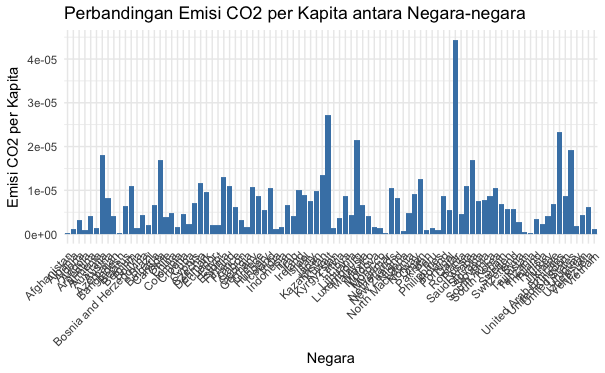

```r
# Membuat visualisasi bar chart
bar_chart <- ggplot(co2_population, aes(x = country, y = co2_per_capita)) +
  geom_bar(stat = "identity", fill = "steelblue") +
  labs(title = "Perbandingan Emisi CO2 per Kapita antara Negara-negara",
       x = "Negara",
       y = "Emisi CO2 per Kapita") +
  theme_minimal() +
  theme(axis.text.x = element_text(angle = 45, hjust = 1))
print(bar_chart)
```

Negara-negara timur tengah mendominasi urutan ini, dengan Qatar berada diposisi pertama diikuti Kuwait dan Uni Emirat Arab.

**Pertanyaan 7** Apakah ada perbedaan dalam pola emisi antara kelompok negara yang berbeda berdasarkan analisis klaster?

Untuk menjawab pertanyaan ini kami akan melakukan analisis klaster menggunakan K-means untuk mendapatkan pendekatan terhadap data yang disediakan.

```r
# Menggabungkan data CO2 dari sumber-sumber yang berbeda menjadi satu dataframe
co2_data <- bind_cols(data_cement, data_coal, data_gas, data_oil, data_flaring)
# Standarisasi data, untuk memastikan bahwa setiap variabel memiliki skala yang serupa.
co2_data_scaled <- scale(co2_data)

# Menerapkan analisis klaster (contoh menggunakan metode K-means dengan 3 kelompok)
kmeans_model <- kmeans(co2_data_scaled, centers = 3)

# Menambahkan informasi kelompok ke dataframe asli
co2_data_clustered <- co2_data %>%
  mutate(cluster = kmeans_model$cluster)

# Melihat hasil klastering
print(co2_data_clustered)
```

| ...1 | ...2 | ...3 | ...4 | ...5 | cluster |
| --- | --- | --- | --- | --- | --- |
| 0.056 | 0.022 | 0.373 | 0.937 | 0.032 | 1 |
| 0.057 | 0.018 | 0.362 | 0.904 | 0.032 | 1 |
| 0.057 | 0.015 | 0.348 | 0.870 | 0.032 | 1 |
| 0.057 | 0.015 | 0.332 | 0.834 | 0.032 | 1 |
| 0.057 | 0.007 | 0.318 | 0.790 | 0.032 | 1 |
| 0.057 | 0.004 | 0.293 | 0.738 | 0.032 | 1 |
| 0.057 | 0.004 | 0.275 | 0.701 | 0.032 | 1 |
| 0.057 | 0.004 | 0.252 | 0.495 | 0.032 | 1 |
| 0.010 | 0.004 | 0.224 | 0.498 | 0.032 | 1 |
| 0.007 | 0.070 | 0.209 | 0.491 | 0.032 | 1 |

[output cut: 990 more lines]

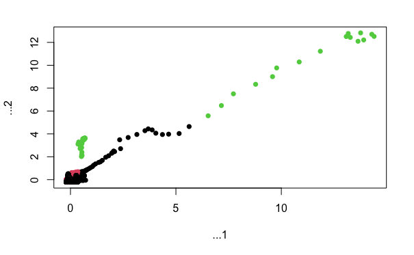

```r
# Visualisasi hasil klastering
plot(co2_data_scaled, col = kmeans_model$cluster, pch = 16)
```

```r
# Menampilkan pusat klaster
centers <- as.data.frame(scale(kmeans_model$centers))
centers$cluster <- 1:3 #length(kmeans_model$centers)
print(centers)
```

|  | ...1 | ...2 | ...3 | ...4 | ...5 | cluster |
| --- | --- | --- | --- | --- | --- | --- |
| 1 | -0.5906792 | -0.5890897 | -0.7328860 | -0.6348916 | -1.1265677 | 1 |
| 2 | -0.5639179 | -0.5655307 | -0.4063174 | -0.5178293 | 0.3438893 | 2 |
| 3 | 1.1545972 | 1.1546204 | 1.1392034 | 1.1527209 | 0.7826784 | 3 |

Didapatkan nilai-nilai koordinat yang mewakili klastering kelompok mana sajakah yang termasuk dalam nilai-nilai tersebut. Selanjutnya kami melakukan perbandingan koordinat pusat antara kluster dan melihat perbedaan relatif dalam karakteristik, serta mem-visualisasikan teman kedalam **diagram batang** untuk melihat perbedaan absolut antara koordinat pusat, dan **diagram garis** untuk melihat tren perubahan relatif antara klaster.

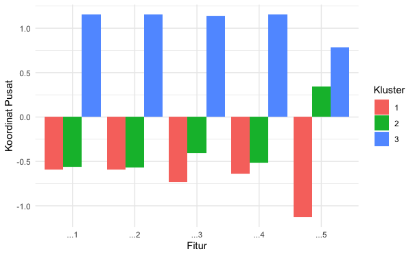

```r
# kami memerlukan satu upaya untuk membandingkan koordinat pusat antara kluster dan melihat perbedaan relatif dalam karakteristik
library(tidyverse)
centers_long <- gather(centers, key = "feature", value = "value", -cluster)

# Visualkan temuan untuk pemahaman lebih lanjut
ggplot(centers_long, aes(x = feature, y = value, fill = factor(cluster))) +
  geom_bar(stat = "identity", position = "dodge") +
  xlab("Fitur") +
  ylab("Koordinat Pusat") +
  scale_fill_discrete(name = "Kluster") +
  theme_minimal()
```

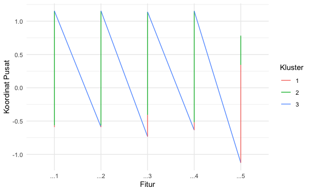

```r
# Mencoba melihat tren perubahan relatif antara klaster
ggplot(centers_long, aes(x = feature, y = value, group = 1, color = factor(cluster))) +
  geom_line() +
  xlab("Fitur") +
  ylab("Koordinat Pusat") +
  scale_color_discrete(name = "Kluster") +
  theme_minimal()
```

Memodifikasi hasil klastering untuk mengelompokkan nama-nama negara yang termasuk dalam masing-masing klaster.

```r
# Menggabungkan nama negara ke dataframe hasil klastering
co2_data_clustered <- co2_data_clustered %>%
  mutate(country = cement$country)

# Mengelompokkan nama negara berdasarkan klaster
clustered_countries <- co2_data_clustered %>%
  select(country, cluster) %>%
  distinct()

# Menampilkan nama-nama negara dalam setiap klaster
for (i in 1:max(kmeans_model$cluster)) {
  cat("Klaster", i, ":", "\n")
  print(clustered_countries$country[clustered_countries$cluster == i])
  cat("\n")
}
```

```
Klaster 1 :
 [1] "Afghanistan"            "Albania"                "Algeria"
 [4] "Angola"                 "Argentina"              "Armenia"
 [7] "Australia"              "Austria"                "Azerbaijan"
[10] "Bangladesh"             "Belarus"                "Belgium"
[13] "Bolivia"                "Bosnia and Herzegovina" "Brazil"
[16] "Bulgaria"               "Chile"                  "China"
[19] "Colombia"               "Croatia"                "Cuba"
[22] "Cyprus"                 "Czechia"                "Denmark"
[25] "Ecuador"                "Egypt"                  "Estonia"
[28] "Finland"                "France"                 "Gabon"
[31] "Georgia"                "Germany"                "Greece"
[34] "Hungary"                "Iceland"                "India"
[37] "Indonesia"              "Iraq"                   "Ireland"
[40] "Israel"                 "Italy"                  "Japan"
```

[output cut: 24 more lines]

### Kesimpulan

Dengan membandingkan emisi CO2 per kapita antara negara-negara, kita dapat melihat perbedaan tingkat emisi antara negara-negara yang memiliki populasi berbeda. Analisis ini dapat memberikan pemahaman tentang negara-negara mana yang memiliki tingkat emisi CO2 yang tinggi atau rendah per penduduknya. Hal ini dapat membantu dalam mengidentifikasi negara-negara yang perlu mengadopsi kebijakan lingkungan yang lebih ketat untuk mengurangi emisi CO2 dan menghadapi tantangan perubahan iklim.

Selain itu, analisis ini juga dapat memberikan gambaran tentang peran populasi dalam kontribusi terhadap emisi CO2. Jika terdapat perbedaan signifikan antara negara-negara dengan populasi yang serupa, hal ini dapat menunjukkan perbedaan dalam pola konsumsi, sektor industri, atau kebijakan lingkungan di masing-masing negara.